# ETM58D HW3 HW4

Muammer Dolmaci

07/03/2021

In the **Introdcution** section; the initial operations will be done and time-series will be plotted.

In the **Analysis** section; the tables, figures and predictions will be commented.

In the **Comparison** section; the obtained results will be compared.

# Introduction

## Libraries

All libraries that we used through the report is given below.

```r
library(readr)
library(ggplot2)
library(MASS)
library(tidyverse)
library(dplyr)
library(lubridate)
library(glmnet)
```

## Data Import

The **Consumption Data** is imported via the code chunk below.

The variable name of imported data is selected `consumptionData` and read the data from the csv file.

```r
consumptionData <- read_csv("GercekZamanliTuketim-01012016-31052021.csv")
str(consumptionData)
```

```
## spec_tbl_df[,3] [47,472 × 3] (S3: spec_tbl_df/tbl_df/tbl/data.frame)
##  $ Tarih  : chr [1:47472] "01.01.2016" "01.01.2016" "01.01.2016" "01.01.2016" ...
##  $ Saat   : 'hms' num [1:47472] 00:00:00 01:00:00 02:00:00 03:00:00 ...
##   ..- attr(*, "units")= chr "secs"
##  $ Tuketim: num [1:47472] 26.3 25 23.5 22.5 22 ...
##  - attr(*, "spec")=
##   .. cols(
##   ..   Tarih = col_character(),
##   ..   Saat = col_time(format = ""),
##   ..   Tuketim = col_number()
##   .. )
```

## Modifications

Some modification are done on the current data via the code chunks below.

```r
modifiedData <- mutate(consumptionData, date=dmy(Tarih), hour = as.character(Saat), hour = substring (hour, 1, 2))
```

The **lag48** and **lag168** sets will be created for **total consumption** with their **errors**. Then they will be added to the `updatedData` as variables.

```r
lag48 <- lag(modifiedData, 48)
lag168 <- lag(modifiedData, 168)

updatedData <- mutate(modifiedData,
                      lag48Tuketim=lag48$Tuketim,
                      lag168Tuketim=lag168$Tuketim,
                      lag48Err=100*abs((lag48$Tuketim - modifiedData$Tuketim)/
                                    modifiedData$Tuketim),
                      lag168Err=100*abs((lag168$Tuketim - modifiedData$Tuketim)/
                                    modifiedData$Tuketim))
```

Data will be filtered according to the time interval as `testPeriod`.

```r
testPeriod <- filter(updatedData, date>=as_date('2021-05-01'))
```

## Descriptive Analysis

**Descriptive Analysis** made by the code chunk below.

```r
summary(testPeriod$lag48Err)
```

```
##     Min.  1st Qu.   Median     Mean  3rd Qu.     Max.
##  0.00384  2.09289  7.30250  9.26289 13.20968 46.71555
```

```r
summary(testPeriod$lag168Err)
```

```
##     Min.  1st Qu.   Median     Mean  3rd Qu.     Max.
##  0.01239  1.35130  4.11998  9.82937 13.74725 60.43751
```

```r
quantile(testPeriod$lag48Err,probs = c(0,0.1,0.25,0.5,0.75,0.9))
```

```
##           0%          10%          25%          50%          75%          90%
##  0.003841994  0.731086953  2.092888146  7.302496843 13.209679560 22.641938385
```

```r
quantile(testPeriod$lag168Err,probs = c(0,0.1,0.25,0.5,0.75,0.9))
```

```
##          0%         10%         25%         50%         75%         90%
##  0.01238552  0.44992574  1.35130473  4.11998310 13.74725400 29.72958914
```

```r
cor(testPeriod$Tuketim,testPeriod$lag48Tuketim)
```

```
## [1] 0.6435983
```

```r
cor(testPeriod$Tuketim,testPeriod$lag168Tuketim)
```

```
## [1] 0.4864695
```

## Graphs

The **graphs** of descriptive analysis summaries are plotted below.

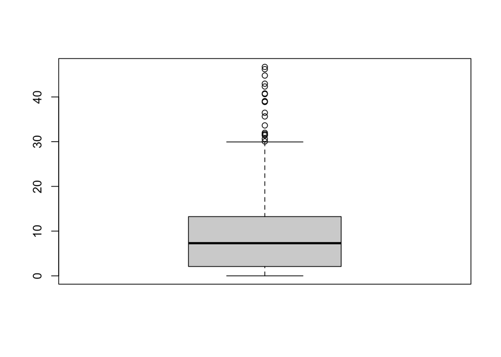

```r
boxplot(testPeriod$lag48Err)
```

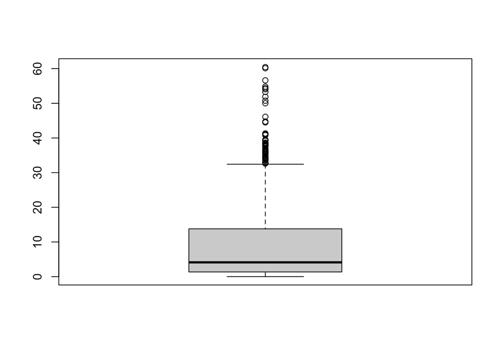

```r
boxplot(testPeriod$lag168Err)
```

The **graph** of **Consumption** through the time is plotted below.

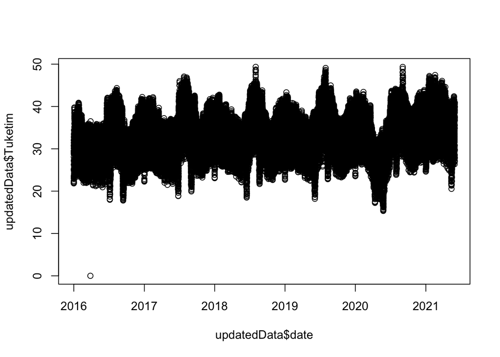

```r
plot(updatedData$date, updatedData$Tuketim)
```

# Analysis

## Linear Regression

First of all, **Linear Regression** will be tried.

```r
linear_model <- lm(Tuketim ~ lag168Tuketim + lag48Tuketim, data=testPeriod)
summary(linear_model)
```

```
##
## Call:
## lm(formula = Tuketim ~ lag168Tuketim + lag48Tuketim, data = testPeriod)
##
## Residuals:
##      Min       1Q   Median       3Q      Max
## -12.1891  -1.5527   0.2807   1.8528   8.4229
##
## Coefficients:
##               Estimate Std. Error t value Pr(>|t|)
## (Intercept)    4.79818    1.09114   4.397 1.26e-05 ***
## lag168Tuketim  0.31137    0.02882  10.804  < 2e-16 ***
## lag48Tuketim   0.54336    0.02799  19.410  < 2e-16 ***
## ---
## Signif. codes:  0 '***' 0.001 '**' 0.01 '*' 0.05 '.' 0.1 ' ' 1
##
## Residual standard error: 3.389 on 741 degrees of freedom
## Multiple R-squared:  0.4939, Adjusted R-squared:  0.4926
## F-statistic: 361.6 on 2 and 741 DF,  p-value: < 2.2e-16
```

According to the linear mode, the **prediction model** is prepared via the code chunk below.

```r
predicted_linear_model <- predict(linear_model, testPeriod)
```

**MAPE** values are calculated for **Linear Regression Prediction Model** to analyze the **accuracy**.

MAPE values are also added to the `testPeriod`.

```r
testPeriod <- mutate(testPeriod, linear_MAPE=100*(abs(testPeriod$Tuketim-predicted_linear_model)/testPeriod$Tuketim))
summary(testPeriod$linear_MAPE)
```

```
##     Min.  1st Qu.   Median     Mean  3rd Qu.     Max.
##  0.01431  2.14149  5.36146  7.84883 10.70347 48.97757
```

# Comparison

The Linear Regression model should be evaluated and established a model to forecast tomorrow.

```r
modal_cons_h0 <- lm(Tuketim ~ lag168Tuketim + lag48Tuketim, data = testPeriod %>% filter(hour == "00"))
modal_cons_h1 <- lm(Tuketim ~ lag168Tuketim + lag48Tuketim, data = testPeriod %>% filter(hour == "01"))
modal_cons_h2 <- lm(Tuketim ~ lag168Tuketim + lag48Tuketim, data = testPeriod %>% filter(hour == "02"))
modal_cons_h3 <- lm(Tuketim ~ lag168Tuketim + lag48Tuketim, data = testPeriod %>% filter(hour == "03"))
modal_cons_h4 <- lm(Tuketim ~ lag168Tuketim + lag48Tuketim, data = testPeriod %>% filter(hour == "04"))
modal_cons_h5 <- lm(Tuketim ~ lag168Tuketim + lag48Tuketim, data = testPeriod %>% filter(hour == "05"))
modal_cons_h6 <- lm(Tuketim ~ lag168Tuketim + lag48Tuketim, data = testPeriod %>% filter(hour == "06"))
modal_cons_h7 <- lm(Tuketim ~ lag168Tuketim + lag48Tuketim, data = testPeriod %>% filter(hour == "07"))
modal_cons_h8 <- lm(Tuketim ~ lag168Tuketim + lag48Tuketim, data = testPeriod %>% filter(hour == "08"))
modal_cons_h9 <- lm(Tuketim ~ lag168Tuketim + lag48Tuketim, data = testPeriod %>% filter(hour == "09"))
modal_cons_h10 <- lm(Tuketim ~ lag168Tuketim + lag48Tuketim, data = testPeriod %>% filter(hour == "10"))
modal_cons_h11 <- lm(Tuketim ~ lag168Tuketim + lag48Tuketim, data = testPeriod %>% filter(hour == "11"))
modal_cons_h12 <- lm(Tuketim ~ lag168Tuketim + lag48Tuketim, data = testPeriod %>% filter(hour == "12"))
modal_cons_h13 <- lm(Tuketim ~ lag168Tuketim + lag48Tuketim, data = testPeriod %>% filter(hour == "13"))
modal_cons_h14 <- lm(Tuketim ~ lag168Tuketim + lag48Tuketim, data = testPeriod %>% filter(hour == "14"))
modal_cons_h15 <- lm(Tuketim ~ lag168Tuketim + lag48Tuketim, data = testPeriod %>% filter(hour == "15"))
modal_cons_h16 <- lm(Tuketim ~ lag168Tuketim + lag48Tuketim, data = testPeriod %>% filter(hour == "16"))
modal_cons_h17 <- lm(Tuketim ~ lag168Tuketim + lag48Tuketim, data = testPeriod %>% filter(hour == "17"))
modal_cons_h18 <- lm(Tuketim ~ lag168Tuketim + lag48Tuketim, data = testPeriod %>% filter(hour == "18"))
modal_cons_h19 <- lm(Tuketim ~ lag168Tuketim + lag48Tuketim, data = testPeriod %>% filter(hour == "19"))
modal_cons_h20 <- lm(Tuketim ~ lag168Tuketim + lag48Tuketim, data = testPeriod %>% filter(hour == "20"))
modal_cons_h21 <- lm(Tuketim ~ lag168Tuketim + lag48Tuketim, data = testPeriod %>% filter(hour == "21"))
modal_cons_h22 <- lm(Tuketim ~ lag168Tuketim + lag48Tuketim, data = testPeriod %>% filter(hour == "22"))
modal_cons_h23 <- lm(Tuketim ~ lag168Tuketim + lag48Tuketim, data = testPeriod %>% filter(hour == "23"))
```

```r
test_set_h0 <- testPeriod %>% filter(hour == "00")
test_set_h1 <- testPeriod %>% filter(hour == "01")
test_set_h2 <- testPeriod %>% filter(hour == "02")
test_set_h3 <- testPeriod %>% filter(hour == "03")
test_set_h4 <- testPeriod %>% filter(hour == "04")
test_set_h5 <- testPeriod %>% filter(hour == "05")
test_set_h6 <- testPeriod %>% filter(hour == "06")
test_set_h7 <- testPeriod %>% filter(hour == "07")
test_set_h8 <- testPeriod %>% filter(hour == "08")
test_set_h9 <- testPeriod %>% filter(hour == "09")
test_set_h10 <- testPeriod %>% filter(hour == "10")
test_set_h11 <- testPeriod %>% filter(hour == "11")
test_set_h12 <- testPeriod %>% filter(hour == "12")
test_set_h13 <- testPeriod %>% filter(hour == "13")
test_set_h14 <- testPeriod %>% filter(hour == "14")
test_set_h15 <- testPeriod %>% filter(hour == "15")
test_set_h16 <- testPeriod %>% filter(hour == "16")
test_set_h17 <- testPeriod %>% filter(hour == "17")
test_set_h18 <- testPeriod %>% filter(hour == "18")
test_set_h19 <- testPeriod %>% filter(hour == "19")
test_set_h20 <- testPeriod %>% filter(hour == "10")
test_set_h21 <- testPeriod %>% filter(hour == "21")
test_set_h22 <- testPeriod %>% filter(hour == "22")
test_set_h23 <- testPeriod %>% filter(hour == "23")
```

Test predictions are prepared hour by hour below.

```r
test_set_pred_h0 <- predict(modal_cons_h0, newdata = test_set_h0)
summary((abs(test_set_h0$Tuketim - test_set_pred_h0) / abs(test_set_h0$Tuketim)) * 100)
```

```
##    Min. 1st Qu.  Median    Mean 3rd Qu.    Max.
##   1.038   2.267   4.372   5.592   6.617  25.305
```

```r
test_set_pred_h1 <- predict(modal_cons_h1, newdata = test_set_h1)
summary((abs(test_set_h1$Tuketim - test_set_pred_h1) / abs(test_set_h1$Tuketim)) * 100)
```

```
##     Min.  1st Qu.   Median     Mean  3rd Qu.     Max.
##  0.02595  2.41522  3.90472  5.63862  6.47449 26.99078
```

```r
test_set_pred_h2 <- predict(modal_cons_h2, newdata = test_set_h2)
summary((abs(test_set_h2$Tuketim - test_set_pred_h2) / abs(test_set_h2$Tuketim)) * 100)
```

```
##    Min. 1st Qu.  Median    Mean 3rd Qu.    Max.
##   0.199   2.233   4.555   6.081   6.663  29.475
```

```r
test_set_pred_h3 <- predict(modal_cons_h3, newdata = test_set_h3)
summary((abs(test_set_h3$Tuketim - test_set_pred_h3) / abs(test_set_h3$Tuketim)) * 100)
```

```
##    Min. 1st Qu.  Median    Mean 3rd Qu.    Max.
##  0.2806  2.2366  4.6100  6.1233  6.1561 29.8452
```

```r
test_set_pred_h4 <- predict(modal_cons_h4, newdata = test_set_h4)
summary((abs(test_set_h4$Tuketim - test_set_pred_h4) / abs(test_set_h4$Tuketim)) * 100)
```

```
##     Min.  1st Qu.   Median     Mean  3rd Qu.     Max.
##  0.04802  2.00028  4.61816  5.96420  6.45027 28.44826
```

```r
test_set_pred_h5 <- predict(modal_cons_h5, newdata = test_set_h5)
summary((abs(test_set_h5$Tuketim - test_set_pred_h5) / abs(test_set_h5$Tuketim)) * 100)
```

```
##     Min.  1st Qu.   Median     Mean  3rd Qu.     Max.
##  0.05587  3.04065  4.94508  6.36603  7.46097 25.17803
```

```r
test_set_pred_h6 <- predict(modal_cons_h6, newdata = test_set_h6)
summary((abs(test_set_h6$Tuketim - test_set_pred_h6) / abs(test_set_h6$Tuketim)) * 100)
```

```
##    Min. 1st Qu.  Median    Mean 3rd Qu.    Max.
##  0.4733  3.2323  5.9313  6.8652  8.3190 25.0726
```

```r
test_set_pred_h7 <- predict(modal_cons_h7, newdata = test_set_h7)
summary((abs(test_set_h7$Tuketim - test_set_pred_h7) / abs(test_set_h7$Tuketim)) * 100)
```

```
##     Min.  1st Qu.   Median     Mean  3rd Qu.     Max.
##  0.05419  3.61794  7.07532  8.18799 10.22171 26.46249
```

```r
test_set_pred_h8 <- predict(modal_cons_h8, newdata = test_set_h8)
summary((abs(test_set_h8$Tuketim - test_set_pred_h8) / abs(test_set_h8$Tuketim)) * 100)
```

```
##    Min. 1st Qu.  Median    Mean 3rd Qu.    Max.
##   1.105   4.640   9.338  11.215  15.056  40.372
```

```r
test_set_pred_h9 <- predict(modal_cons_h9, newdata = test_set_h9)
summary((abs(test_set_h9$Tuketim - test_set_pred_h9) / abs(test_set_h9$Tuketim)) * 100)
```

```
##    Min. 1st Qu.  Median    Mean 3rd Qu.    Max.
##  0.9034  4.7975  9.2861 11.6235 16.0217 43.9876
```

```r
test_set_pred_h10 <- predict(modal_cons_h10, newdata = test_set_h10)
summary((abs(test_set_h10$Tuketim - test_set_pred_h10) / abs(test_set_h10$Tuketim)) * 100)
```

```
##    Min. 1st Qu.  Median    Mean 3rd Qu.    Max.
##  0.2856  4.2245  8.7103 10.9000 14.8288 43.8096
```

```r
test_set_pred_h11 <- predict(modal_cons_h11, newdata = test_set_h11)
summary((abs(test_set_h11$Tuketim - test_set_pred_h11) / abs(test_set_h11$Tuketim)) * 100)
```

```
##     Min.  1st Qu.   Median     Mean  3rd Qu.     Max.
##  0.08462  4.36261  8.26689 10.42401 13.68964 45.98997
```

```r
test_set_pred_h12 <- predict(modal_cons_h12, newdata = test_set_h12)
summary((abs(test_set_h12$Tuketim - test_set_pred_h12) / abs(test_set_h12$Tuketim)) * 100)
```

```
##    Min. 1st Qu.  Median    Mean 3rd Qu.    Max.
##   0.250   2.872   7.213   9.011  11.830  43.167
```

```r
test_set_pred_h13 <- predict(modal_cons_h13, newdata = test_set_h13)
summary((abs(test_set_h13$Tuketim - test_set_pred_h13) / abs(test_set_h13$Tuketim)) * 100)
```

```
##    Min. 1st Qu.  Median    Mean 3rd Qu.    Max.
##  0.1796  2.9971  8.0248  8.9215 11.5800 45.0527
```

```r
test_set_pred_h14 <- predict(modal_cons_h14, newdata = test_set_h14)
summary((abs(test_set_h14$Tuketim - test_set_pred_h14) / abs(test_set_h14$Tuketim)) * 100)
```

```
##    Min. 1st Qu.  Median    Mean 3rd Qu.    Max.
##   0.255   4.534   8.263   9.983  12.408  48.853
```

```r
test_set_pred_h15 <- predict(modal_cons_h15, newdata = test_set_h15)
summary((abs(test_set_h15$Tuketim - test_set_pred_h15) / abs(test_set_h15$Tuketim)) * 100)
```

```
##     Min.  1st Qu.   Median     Mean  3rd Qu.     Max.
##  0.06322  4.10137  8.57536 10.06933 12.13788 49.27936
```

```r
test_set_pred_h16 <- predict(modal_cons_h16, newdata = test_set_h16)
summary((abs(test_set_h16$Tuketim - test_set_pred_h16) / abs(test_set_h16$Tuketim)) * 100)
```

```
##     Min.  1st Qu.   Median     Mean  3rd Qu.     Max.
##  0.04379  4.19658  8.65644  9.96105 12.19990 47.20156
```

```r
test_set_pred_h17 <- predict(modal_cons_h17, newdata = test_set_h17)
summary((abs(test_set_h17$Tuketim - test_set_pred_h17) / abs(test_set_h17$Tuketim)) * 100)
```

```
##     Min.  1st Qu.   Median     Mean  3rd Qu.     Max.
##  0.07511  4.17940  7.98079  9.15116 11.26177 42.79000
```

```r
test_set_pred_h18 <- predict(modal_cons_h18, newdata = test_set_h18)
summary((abs(test_set_h18$Tuketim - test_set_pred_h18) / abs(test_set_h18$Tuketim)) * 100)
```

```
##    Min. 1st Qu.  Median    Mean 3rd Qu.    Max.
##  0.7226  3.2909  6.3440  7.9103  8.9882 38.9099
```

```r
test_set_pred_h19 <- predict(modal_cons_h19, newdata = test_set_h19)
summary((abs(test_set_h19$Tuketim - test_set_pred_h19) / abs(test_set_h19$Tuketim)) * 100)
```

```
##    Min. 1st Qu.  Median    Mean 3rd Qu.    Max.
##   1.920   3.430   4.652   6.937   8.345  34.415
```

```r
test_set_pred_h20 <- predict(modal_cons_h20, newdata = test_set_h20)
summary((abs(test_set_h20$Tuketim - test_set_pred_h20) / abs(test_set_h20$Tuketim)) * 100)
```

```
##    Min. 1st Qu.  Median    Mean 3rd Qu.    Max.
##  0.3443  3.6593  9.7491 11.3112 17.0538 41.9702
```

```r
test_set_pred_h21 <- predict(modal_cons_h21, newdata = test_set_h21)
summary((abs(test_set_h21$Tuketim - test_set_pred_h21) / abs(test_set_h21$Tuketim)) * 100)
```

```
##    Min. 1st Qu.  Median    Mean 3rd Qu.    Max.
##   0.648   2.465   4.832   5.790   6.275  27.535
```

```r
test_set_pred_h22 <- predict(modal_cons_h22, newdata = test_set_h22)
summary((abs(test_set_h22$Tuketim - test_set_pred_h22) / abs(test_set_h22$Tuketim)) * 100)
```

```
##    Min. 1st Qu.  Median    Mean 3rd Qu.    Max.
##  0.1212  2.8644  5.1463  5.9193  6.5331 26.7556
```

```r
test_set_pred_h23 <- predict(modal_cons_h23, newdata = test_set_h23)
summary((abs(test_set_h23$Tuketim - test_set_pred_h23) / abs(test_set_h23$Tuketim)) * 100)
```

```
##    Min. 1st Qu.  Median    Mean 3rd Qu.    Max.
##  0.5373  2.8977  4.5805  5.7050  6.5911 26.0266
```

# Conclusion